# Part II - (Explanatory Data Visualization of the 2012 PISA DATA)

## by (Oluwashina Dedenuola)

## Investigation Overview

The overall goal of this presentation is to present key insights into the analysis carried out on the PISA 2012 Dataset.

Four main visualizations—two from the bivariate exploration and two from the multivariate exploration—will be my main focus.

I'll concentrate on the bivariate count plot, correlation plot, and regression plots that illustrated the relationship between two variables and their distribution according to gender. I was curious to find out if students who did well in one subject had an impact in another. The Multivariate relationship between the student scores will then be evaluated.

I'll stick with the exploratory analysis's chosen visualizations.

## Dataset Overview

The dataset has Six Hundred and Thirt Six(636) columns and Four Hundred and Eighty Five Thousand, Four Hundred and Ninety Columns with data types which consists of floats, integers and objects. I selected just 29 columns of interest from the entire dataset. I also removed rows with null values prior to establishing relationships between variables.

## (Visualization 1)

To represent the gender distribution of the students who enjoy math lessons, I will plot a countplot.

In general, the majority of students don't think they enjoy math lessons, and the majority of them are female. More female than male disagree with the statement that they enjoy math.

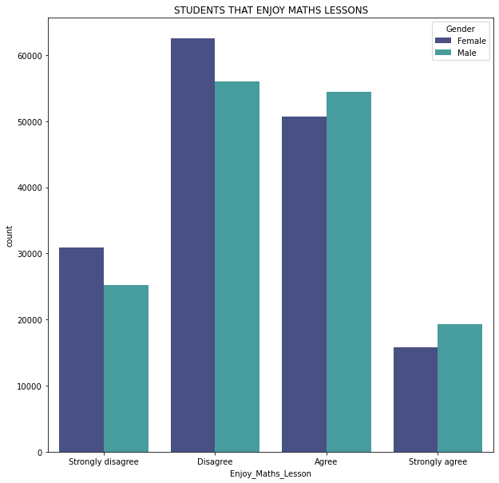

## (Visualization 2)

To represent the gender distribution of the students and the correlation between their Math and Science Scores, I will create a scatterplot.

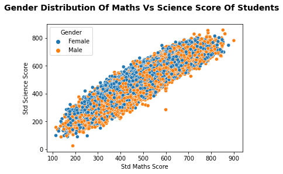

## (Visualization 3)

The regplot suggests a positive weak regression line, which suggests that some students who are open to problem-solving have a tendency to perform very well on their math assessments.

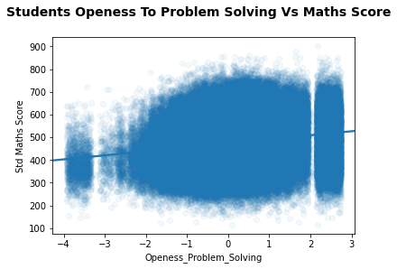

## (Visualization 4)

To express the correlation between the student scores and further substantiate the findings of the bivariate analysis, I will plot a Pairgrid.

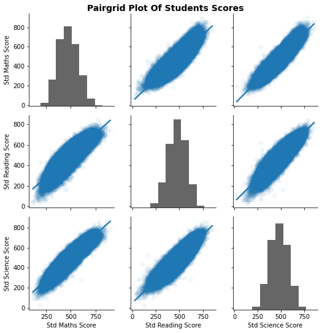